# A quick tour of mclustAddons

Luca Scrucca

02 Apr 2025

# Introduction

**mclustAddons** is a contributed R package that extends the functionality available in the **mclust** package (Scrucca et al. 2016, Scrucca et al. 2023).  
In particular, the following methods are included:

- density estimation for data with bounded support (Scrucca, 2019);
- modal clustering using modal EM algorithm for Gaussian mixtures (Scrucca, 2021);
- entropy estimation via Gaussian mixture modeling (Robin & Scrucca, 2023).

This document gives a quick tour of **mclustAddons** (version 0.9.2). It was written in [R Markdown](https://rmarkdown.rstudio.com), using the knitr package for production.

References on the methodologies implemented are provided at the end of this document.

```r
library(mclustAddons)
```

# Density estimation for data with bounded support

## Univariate case with lower bound

```r
x <- rchisq(200, 3)
xgrid <- seq(-2, max(x), length=1000)
f <- dchisq(xgrid, 3)  # true density
dens <- densityMclustBounded(x, lbound = 0)
summary(dens, parameters = TRUE)
```

```
## ── Density estimation for bounded data via GMMs ───────────
##
## Boundaries:   x
##       lower   0
##       upper Inf
##
## Model E (univariate, equal variance) model with 1 component
## on the transformation scale:
##
##  log-likelihood   n df       BIC       ICL
##       -390.0517 200  3 -795.9983 -795.9983
##
##                                     x
## Range-power transformation: 0.3715163
##
## Mixing probabilities:
## 1
## 1
##
## Means:
##         1
## 0.9191207
##
## Variances:
##        1
## 1.309037
```

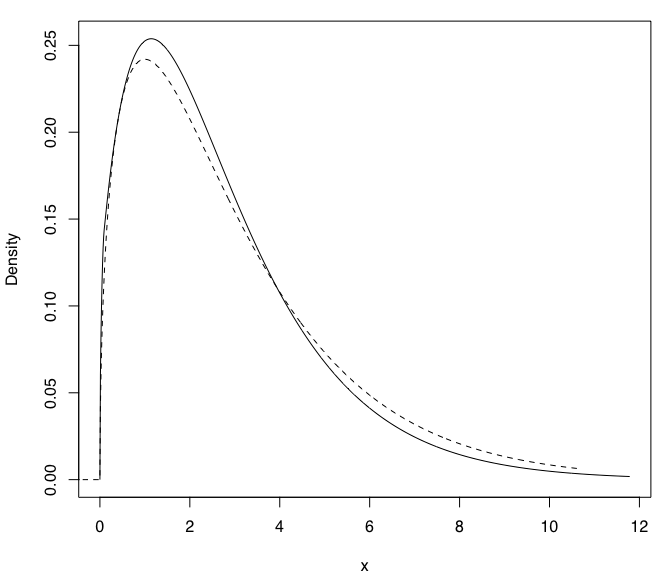

```r
plot(dens, what = "density")
lines(xgrid, f, lty = 2)
```

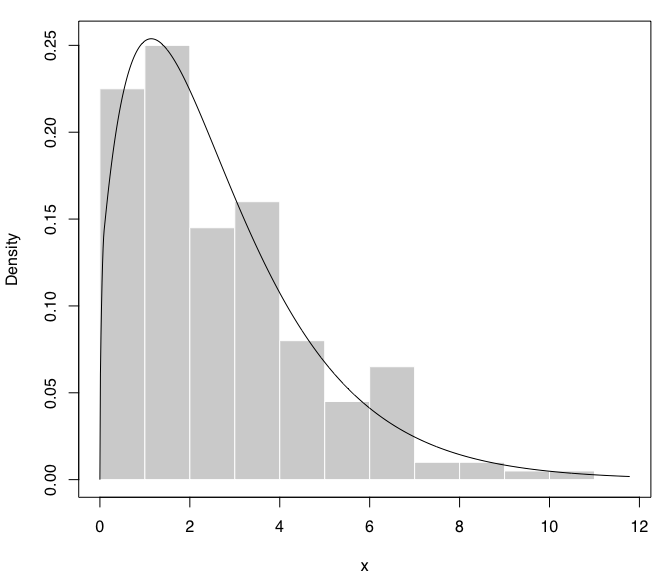

```r
plot(dens, what = "density", data = x, breaks = 15)
```

## Univariate case with lower & upper bounds

```r
x <- rbeta(200, 5, 1.5)
xgrid <- seq(-0.1, 1.1, length=1000)
f <- dbeta(xgrid, 5, 1.5)  # true density
dens <- densityMclustBounded(x, lbound = 0, ubound = 1)
summary(dens, parameters = TRUE)
```

```
## ── Density estimation for bounded data via GMMs ───────────
##
## Boundaries: x
##       lower 0
##       upper 1
##
## Model E (univariate, equal variance) model with 1 component
## on the transformation scale:
##
##  log-likelihood   n df      BIC      ICL
##        120.4011 200  3 224.9072 224.9072
##
##                                      x
## Range-power transformation: -0.2200992
##
## Mixing probabilities:
## 1
## 1
##
## Means:
##        1
## 1.152107
##
## Variances:
##         1
## 0.5212129
```

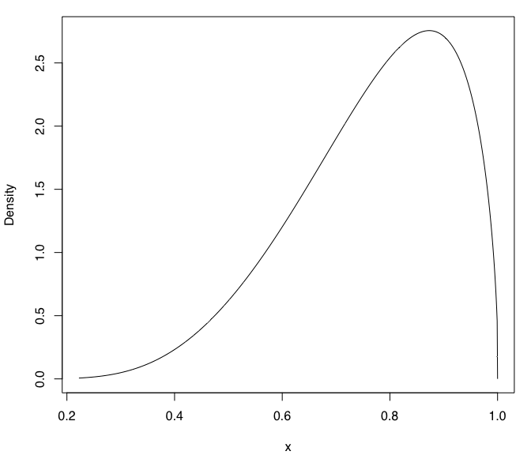

```r
plot(dens, what = "density")
```

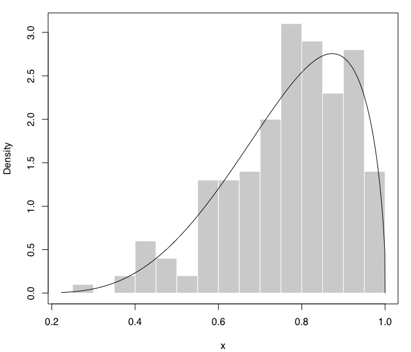

```r
plot(dens, what = "density", data = x, breaks = 11)
```

## Bivariate case with lower bounds

```r
x1 <- rchisq(200, 3)
x2 <- 0.5*x1 + sqrt(1-0.5^2)*rchisq(200, 5)
x <- cbind(x1, x2)
dens <- densityMclustBounded(x, lbound = c(0,0))
summary(dens, parameters = TRUE)
```

```
## ── Density estimation for bounded data via GMMs ───────────
##
## Boundaries:  x1  x2
##       lower   0   0
##       upper Inf Inf
##
## Model EVV (ellipsoidal, equal volume) model with 1 component
## on the transformation scale:
##
##  log-likelihood   n df       BIC       ICL
##       -889.6179 200  7 -1816.324 -1816.324
##
##                                    x1        x2
## Range-power transformation: 0.3060001 0.2725328
##
## Mixing probabilities:
## 1
## 1
##
## Means:
##        [,1]
## x1 1.051800
## x2 2.111525
##
## Variances:
## [,,1]
##           x1        x2
## x1 1.2880789 0.3716033
## x2 0.3716033 0.7138729
```

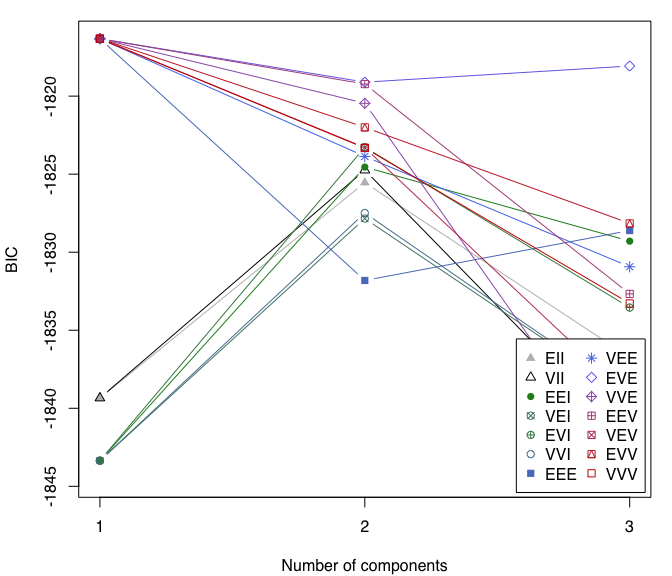

```r
plot(dens, what = "BIC")
```

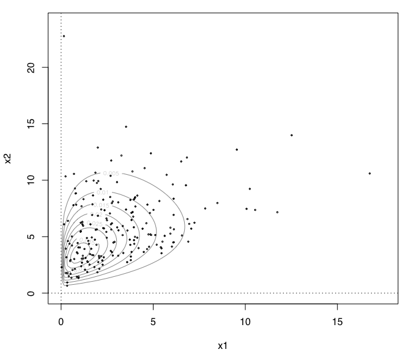

```r
plot(dens, what = "density")
points(x, cex = 0.3)
abline(h = 0, v = 0, lty = 3)
```

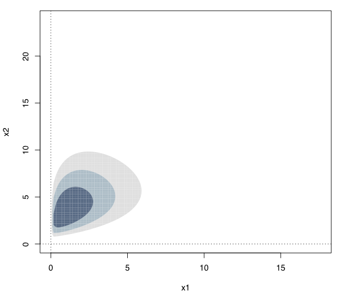

```r
plot(dens, what = "density", type = "hdr")
abline(h = 0, v = 0, lty = 3)
```

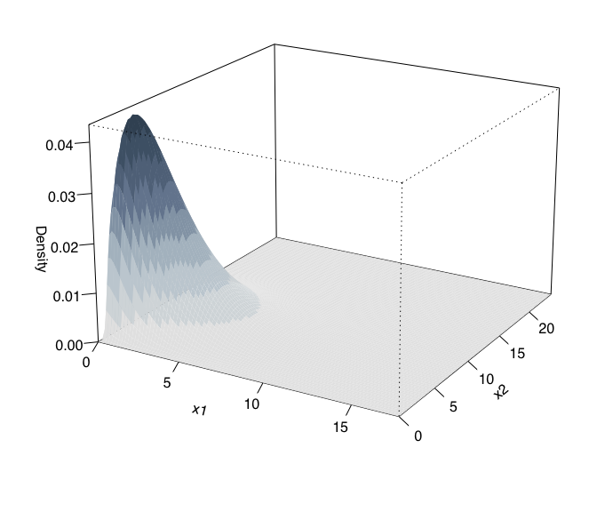

```r
plot(dens, what = "density", type = "persp")
```

## Suicide data

The data consist in the lengths of 86 spells of psychiatric treatment undergone by control patients in a suicide study (Silverman, 1986).

```r
data("suicide")
dens <- densityMclustBounded(suicide, lbound = 0)
summary(dens, parameters = TRUE)
```

```
## ── Density estimation for bounded data via GMMs ───────────
##
## Boundaries: suicide
##       lower       0
##       upper     Inf
##
## Model E (univariate, equal variance) model with 1 component
## on the transformation scale:
##
##  log-likelihood  n df       BIC       ICL
##       -497.8204 86  3 -1009.004 -1009.004
##
##                               suicide
## Range-power transformation: 0.1929267
##
## Mixing probabilities:
## 1
## 1
##
## Means:
##        1
## 6.700073
##
## Variances:
##        1
## 7.788326
```

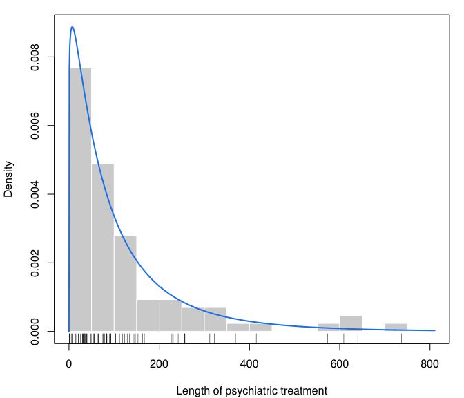

```r
plot(dens, what = "density",
     lwd = 2, col = "dodgerblue2",
     data = suicide, breaks = 15,
     xlab = "Length of psychiatric treatment")
rug(suicide)
```

## Racial data

This dataset provides the proportion of white student enrollment in 56 school districts in Nassau County (Long Island, New York), for the 1992-1993 school year (Simonoff 1996, Sec. 3.2).

```r
data("racial")
x <- racial$PropWhite
dens <- densityMclustBounded(x, lbound = 0, ubound = 1)
summary(dens, parameters = TRUE)
```

```
## ── Density estimation for bounded data via GMMs ───────────
##
## Boundaries: x
##       lower 0
##       upper 1
##
## Model E (univariate, equal variance) model with 1 component
## on the transformation scale:
##
##  log-likelihood  n df      BIC      ICL
##         42.4598 56  3 72.84355 72.84355
##
##                                     x
## Range-power transformation: 0.3869476
##
## Mixing probabilities:
## 1
## 1
##
## Means:
##        1
## 2.795429
##
## Variances:
##        1
## 5.253254
```

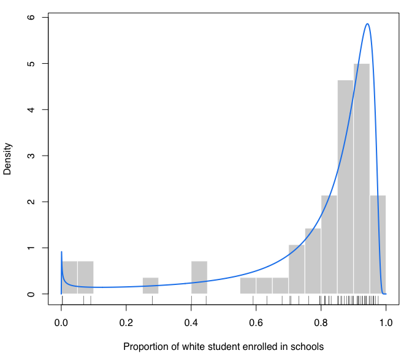

```r
plot(dens, what = "density",
     lwd = 2, col = "dodgerblue2",
     data = x, breaks = 15,
     xlab = "Proportion of white student enrolled in schools")
rug(x)
```

# Modal clustering using MEM algorithm for Gaussian mixtures

## Simulated datasets

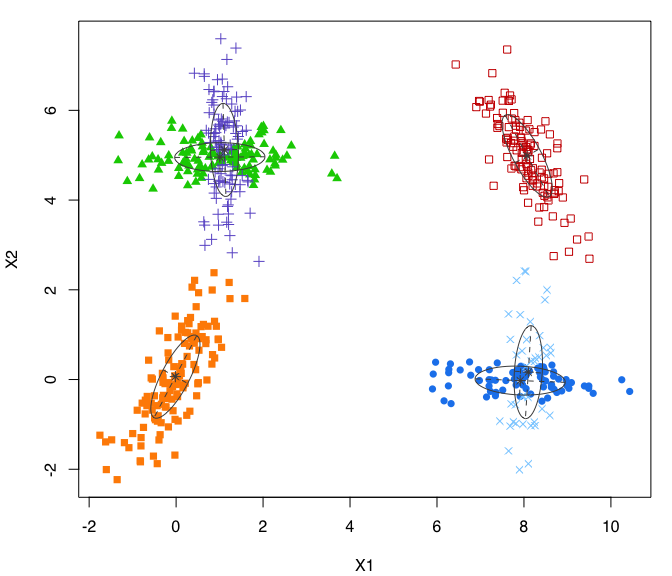

```r
data(Baudry_etal_2010_JCGS_examples, package = "mclust")
GMM <- Mclust(ex4.1)
plot(GMM, what = "classification")
```

```r
MEM <- MclustMEM(GMM)
summary(MEM)
```

```
## ── Modal EM for GMMs ───────────────────
##
## Data dimensions = 600 x 2
## Mclust model    = EEV,6
## MEM iterations  = 17
## Number of modes = 4
##
## Modes:
##                X1          X2
## mode1  8.06741504 -0.01772230
## mode2  8.07370160  4.98485099
## mode3  1.10622966  4.97230749
## mode4 -0.01639289  0.06464381
##
## Modal clustering:
##   1   2   3   4
## 118 122 228 132
```

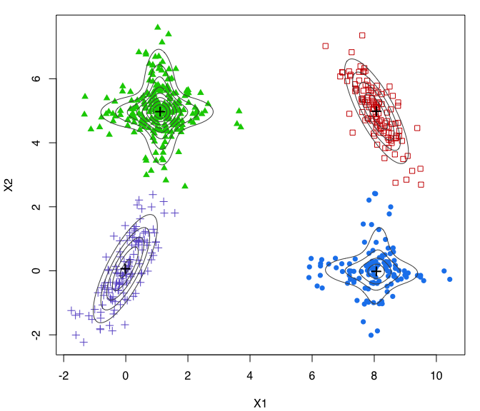

```r
plot(MEM)
```

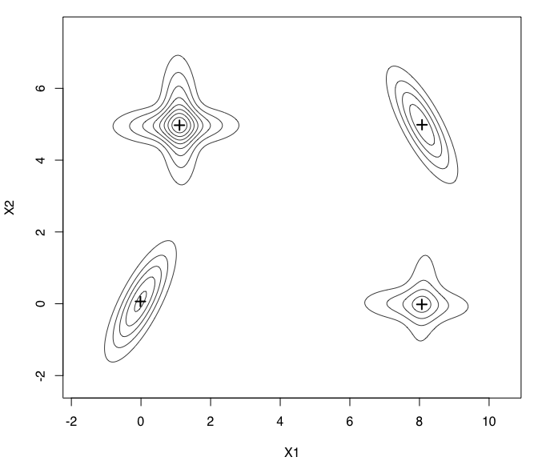

```r
plot(MEM, addPoints = FALSE)
```

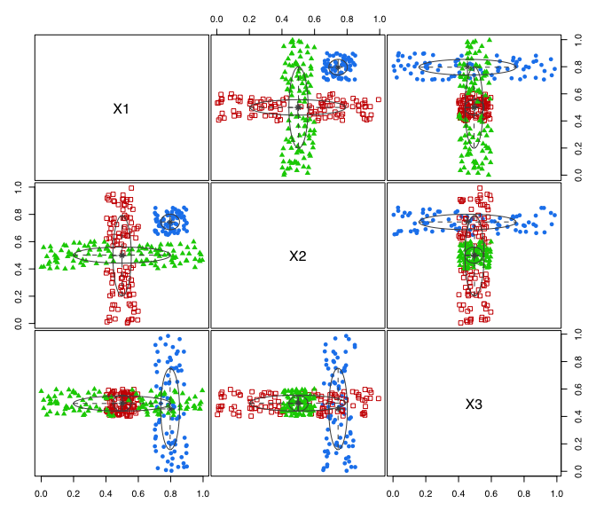

```r
GMM <- Mclust(ex4.4.2)
plot(GMM, what = "classification")
```

```r
MEM <- MclustMEM(GMM)
summary(MEM)
```

```
## ── Modal EM for GMMs ───────────────────
##
## Data dimensions = 300 x 3
## Mclust model    = EVI,3
## MEM iterations  = 15
## Number of modes = 2
##
## Modes:
##              X1        X2        X3
## mode1 0.7964915 0.7444244 0.4547285
## mode2 0.4996361 0.5014374 0.4957522
##
## Modal clustering:
##   1   2
##  78 222
```

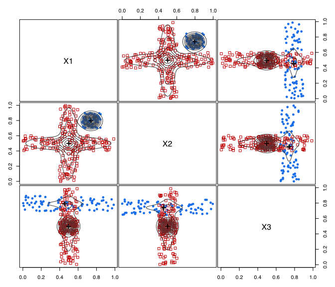

```r
plot(MEM)
```

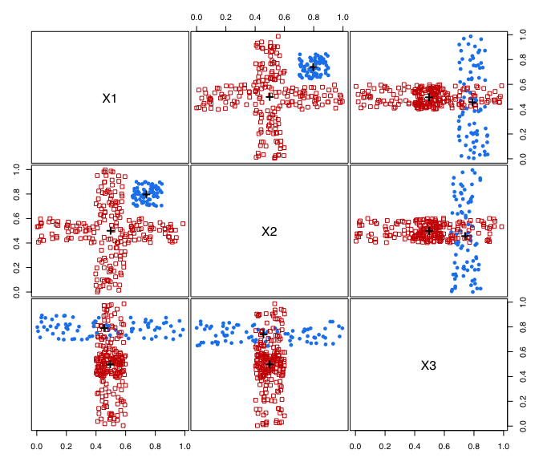

```r
plot(MEM, addDensity = FALSE)
```

# Entropy estimation

## Simulated data

**Univariate Gaussian**

```r
EntropyGauss(1)       # population entropy
```

```
## [1] 1.418939
```

```r
x = rnorm(1000)       # generate sample
EntropyGauss(var(x))  # sample entropy assuming Gaussian distribution
```

```
## [1] 1.384565
```

```r
mod = densityMclust(x, plot = FALSE)
EntropyGMM(mod)       # GMM-based entropy estimate
```

```
## [1] 1.384065
```

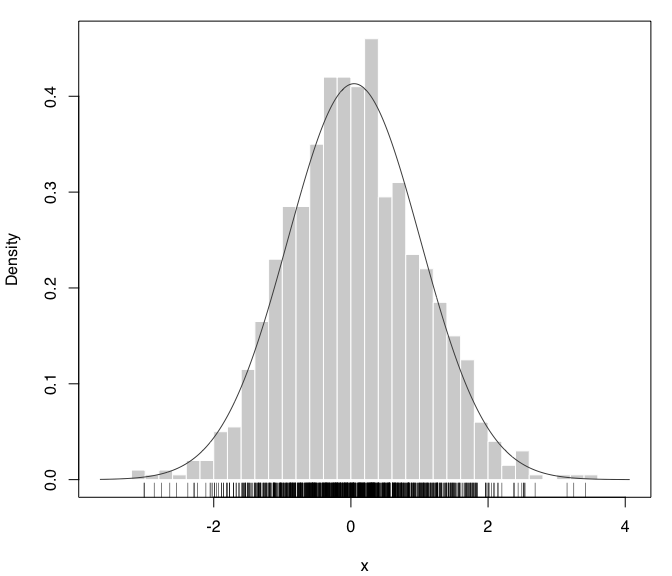

```r
plot(mod, what = "density", data = x, breaks = 31); rug(x)
```

**Univariate Mixed-Gaussian**  
Consider the mixed-Gaussian distribution $f(x) = 0.5 \times N(-2,1) + 0.5 \times N(2,1)$, whose entropy is 2.051939 in the population.

```r
cl = rbinom(1000, size = 1, prob = 0.5)
x = ifelse(cl == 1, rnorm(1000, 2, 1), rnorm(1000, -2, 1))   # generate sample
mod = densityMclust(x, plot = FALSE)
EntropyGMM(mod)       # GMM-based entropy estimate
```

```
## [1] 2.037679
```

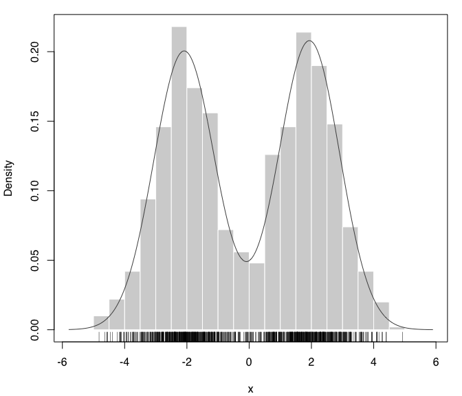

```r
plot(mod, what = "density", data = x, breaks = 31); rug(x)
```

**Multivariate Chi-squared**  
Consider a 10-dimensional independent $\chi^2$ distribution, whose entropy is 24.23095 in the population.

```r
x = matrix(rchisq(1000*10, df = 5), nrow = 1000, ncol = 10)
mod1 = densityMclust(x, plot = FALSE)
EntropyGMM(mod1)      # GMM-based entropy estimate, not too bad but...
```

```
## [1] 25.01403
```

```r
mod2 = densityMclustBounded(x, lbound = rep(0,10))
EntropyGMM(mod2)      # much more accurate
```

```
## [1] 24.22231
```

## Faithful data

```r
data(faithful)
mod = densityMclust(faithful, plot = FALSE)
EntropyGMM(mod)       # GMM-based entropy estimate
```

```
## [1] 4.140889
```

```r
# or provide the data and fit GMM implicitly
EntropyGMM(faithful)
```

```
## [1] 4.140889
```

## Iris data

```r
data(iris)
mod = densityMclust(iris[,1:4], plot = FALSE)
EntropyGMM(mod)       # GMM-based entropy estimate
```

```
## [1] 1.438173
```

# Volatility analysis of financial log-returns

## Gold price 2023 data

```r
data(gold)
head(gold)
```

```
##         date   log.returns
## 1 2023-01-03  0.0109308628
## 2 2023-01-04  0.0070955464
## 3 2023-01-05 -0.0097625244
## 4 2023-01-06  0.0158964701
## 5 2023-01-09  0.0045492333
## 6 2023-01-10 -0.0005875467
```

```r
# GMM modeling
mod = GMMlogreturn(gold$log.returns)
summary(mod)
```

```
## ── Log-returns density estimation via Gaussian finite mixture modeling ─────────
## Model: GMM(V,2)
## Prior: defaultPrior()
##
##  log-likelihood   n df    BIC Entropy
##          852.46 250  5 1677.3 -3.4098
##
## Mixture parameters:
##      Prob       Mean     StDev
## 1 0.52433 0.00029069 0.0045432
## 2 0.47567 0.00073238 0.0107633
##
## Marginal statistics:
##        Mean     StDev Skewness Kurtosis      VaR       ES
##  0.00050079 0.0081227 0.058714   4.5584 0.012877 0.017929
```

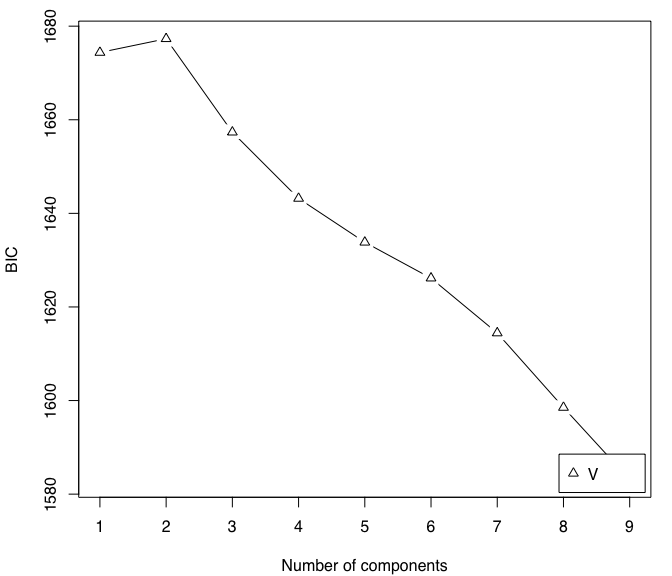

```r
plot(mod, what = "BIC")
```

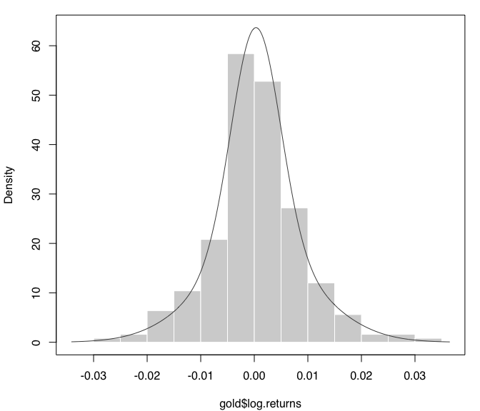

```r
plot(mod, what = "density", data = gold$log.returns)
```

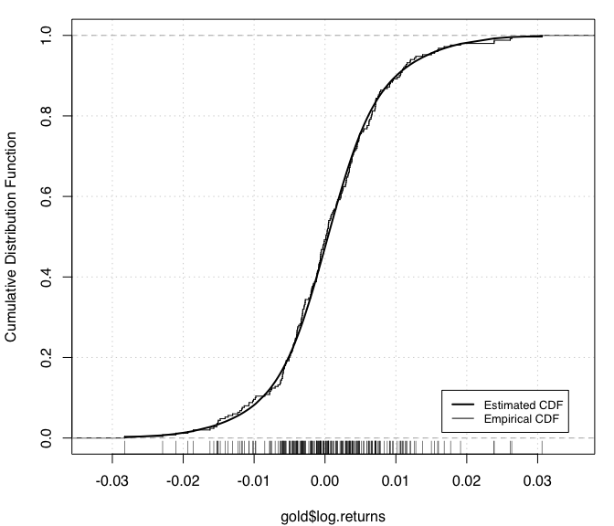

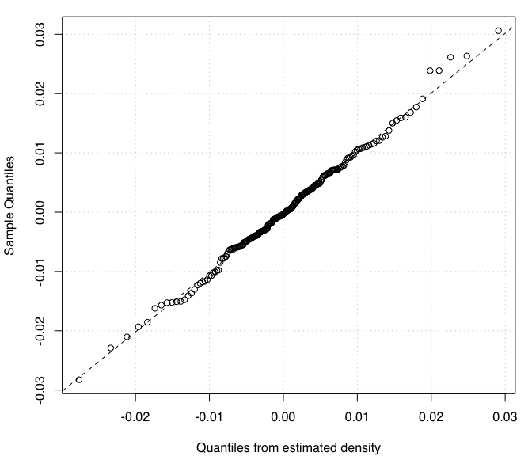

```r
plot(mod, what = "diagnostic")
```

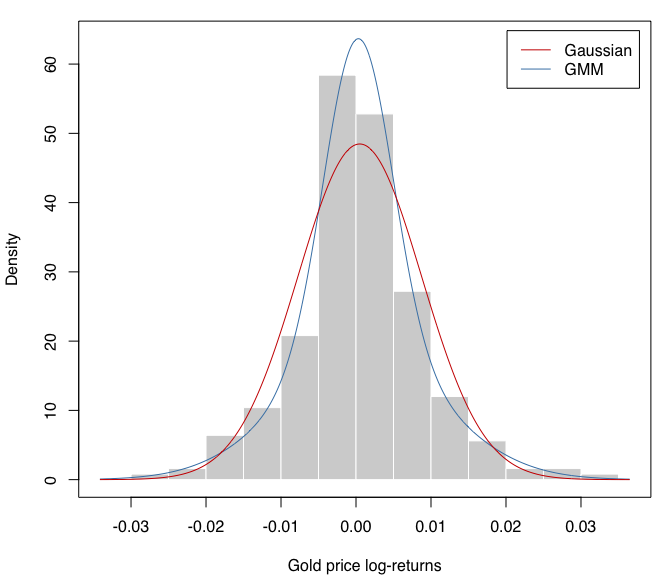

```r
# compare to single Gaussian model
mod1 = GMMlogreturn(gold$log.returns, G = 1)
y0 = extendrange(mod$data, f = 0.1)
y0 = seq(min(y0), max(y0), length = 1000)
plot(mod, what = "density", data = gold$log.returns, col = "steelblue",
     xlab = "Gold price log-returns", ylab = "Density")
lines(y0, predict(mod1, what = "dens", newdata = y0), col = "red3")
legend("topright", legend = c("Gaussian", "GMM"), lty = c(1,1),
       col = c("red3", "steelblue"), inset = 0.02)
```

# References

Scrucca L., Fraley C., Murphy T. B. and Raftery A. E. (2023) *Model-Based Clustering, Classification, and Density Estimation Using mclust in R*. Chapman & Hall/CRC, ISBN: 978-1032234953, https://mclust-org.github.io/book/

Scrucca L., Fop M., Murphy T. B. and Raftery A. E. (2016) mclust 5: clustering, classification and density estimation using Gaussian finite mixture models. *The R Journal* 8/1, pp. 289-317. https://doi.org/10.32614/RJ-2016-021

Scrucca L. (2019) A transformation-based approach to Gaussian mixture density estimation for bounded data, *Biometrical Journal*, 61:4, 873–888. https://doi.org/10.1002/bimj.201800174

Scrucca L. (2021) A fast and efficient Modal EM algorithm for Gaussian mixtures. *Statistical Analysis and Data Mining*, 14:4, 305–314. https://doi.org/10.1002/sam.11527

Robin S. and Scrucca L. (2023) Mixture-based estimation of entropy. *Computational Statistics & Data Analysis*, 177, 107582. https://doi.org/10.1016/j.csda.2022.107582